# Stats 506 (F20) Group Project

#### R

The library `splines` is required for implementing splines by using R.

```r
library(splines)
```

First, considering the linear regression.

```r
model <- lm(wage ~ age + education + year, data = data)
summary(model)
```

```
##
## Call:
## lm(formula = wage ~ age + education + year, data = data)
##
## Residuals:
##      Min       1Q   Median       3Q      Max
## -113.323  -19.521   -3.964   14.438  219.172
##
## Coefficients:
##                               Estimate Std. Error t value Pr(>|t|)
## (Intercept)                 -2.058e+03  6.493e+02  -3.169  0.00154 **
## age                          5.621e-01  5.714e-02   9.838  < 2e-16 ***
## education2. HS Grad          1.140e+01  2.476e+00   4.603 4.34e-06 ***
## education3. Some College     2.423e+01  2.606e+00   9.301  < 2e-16 ***
## education4. College Grad     3.974e+01  2.586e+00  15.367  < 2e-16 ***
## education5. Advanced Degree  6.485e+01  2.804e+00  23.128  < 2e-16 ***
## year                         1.056e+00  3.238e-01   3.262  0.00112 **
## ---
## Signif. codes:  0 '***' 0.001 '**' 0.01 '*' 0.05 '.' 0.1 ' ' 1
##
## Residual standard error: 35.89 on 2993 degrees of freedom
## Multiple R-squared:  0.2619, Adjusted R-squared:  0.2604
## F-statistic:   177 on 6 and 2993 DF,  p-value: < 2.2e-16
```

The $R^2$ is 0.2619, which is pretty low. Consider the scatter plot between `Wage` and `Age`.

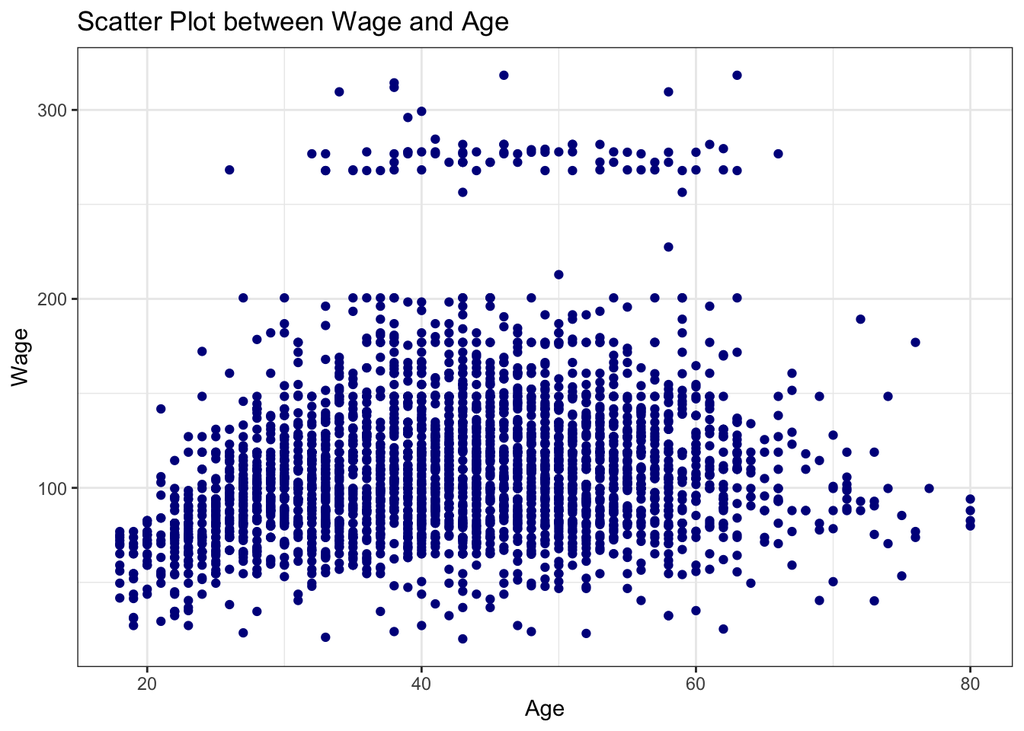

Figure 3.1 Scatter plot between Wage and Age

The scatter plot show that the relationship between these two variables are not linear. Hence, we will try various types of spline.

##### Step Function

Consider applying the step function on `Age`.

```r
model_cut <- lm(wage ~ cut(age, 4) + education + year, data = data)
summary(model_cut)
```

```
##
## Call:
## lm(formula = wage ~ cut(age, 4) + education + year, data = data)
##
## Residuals:
##      Min       1Q   Median       3Q      Max
## -120.260  -19.442   -3.744   14.441  214.958
##
## Coefficients:
##                               Estimate Std. Error t value Pr(>|t|)
## (Intercept)                 -2408.5219   641.1663  -3.756 0.000176 ***
## cut(age, 4)(33.5,49]           20.9265     1.6085  13.010  < 2e-16 ***
## cut(age, 4)(49,64.5]           19.3732     1.8197  10.646  < 2e-16 ***
## cut(age, 4)(64.5,80.1]          8.0516     4.3783   1.839 0.066014 .
## education2. HS Grad            11.1534     2.4436   4.564 5.21e-06 ***
## education3. Some College       24.1620     2.5739   9.387  < 2e-16 ***
## education4. College Grad       39.2164     2.5533  15.359  < 2e-16 ***
## education5. Advanced Degree    64.1642     2.7675  23.185  < 2e-16 ***
## year                            1.2356     0.3197   3.865 0.000113 ***
## ---
## Signif. codes:  0 '***' 0.001 '**' 0.01 '*' 0.05 '.' 0.1 ' ' 1
##
## Residual standard error: 35.39 on 2991 degrees of freedom
## Multiple R-squared:  0.2828, Adjusted R-squared:  0.2809
## F-statistic: 147.4 on 8 and 2991 DF,  p-value: < 2.2e-16
```

The $R^2$ is 0.2828, which improved from the previous model. The plot below is a scatterplot between `Wage` and `Age`, also the yellow line represents the step function.

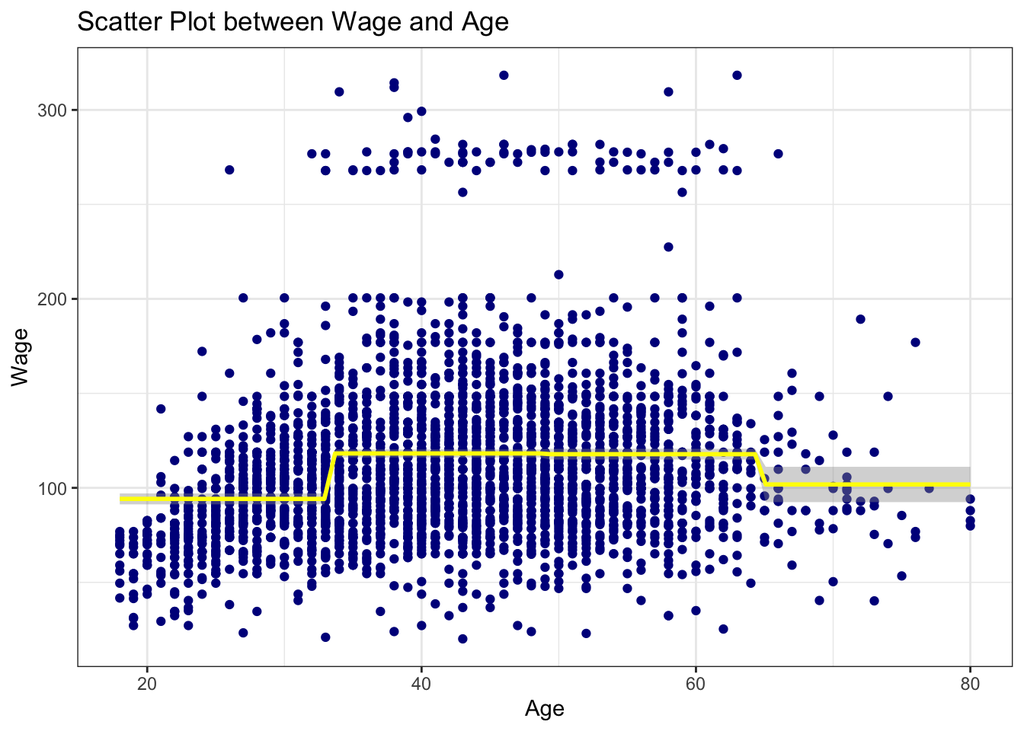

Figure 3.2 Scatter plot between Wage and Age with the step function.

##### Polynomial Regression

Consider the various number for the degree in the polynomial regression. The plots below are the result from the fitting polynomial regression.

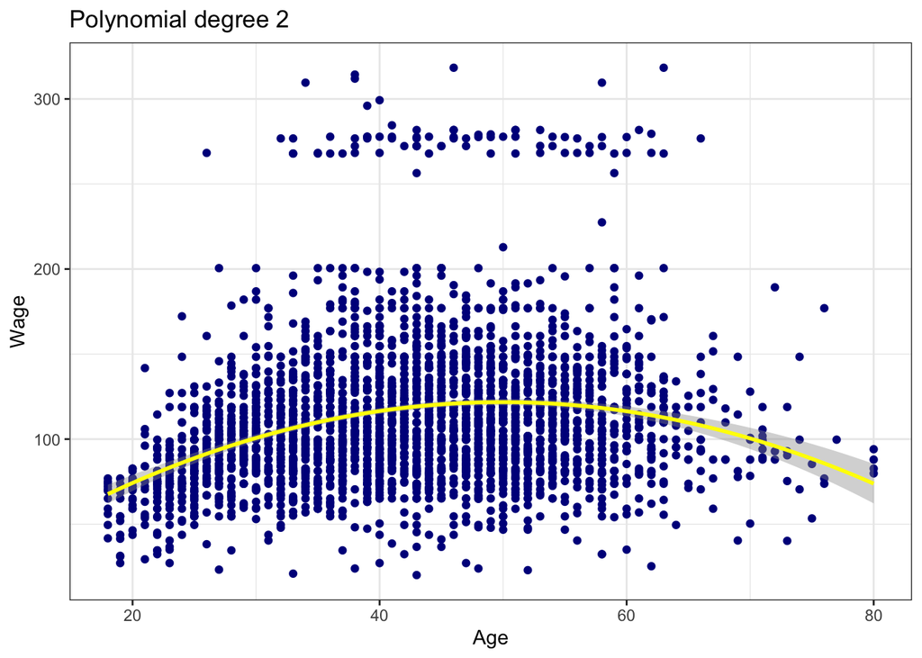

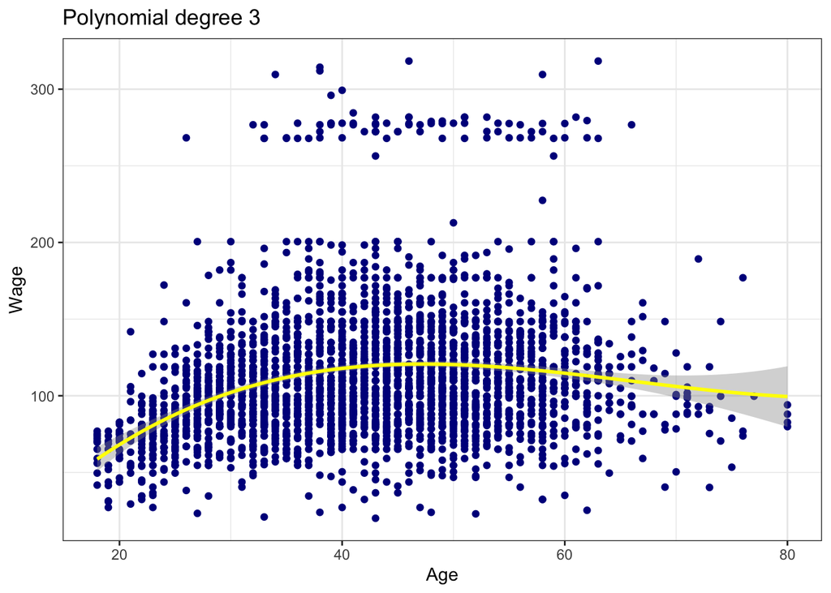

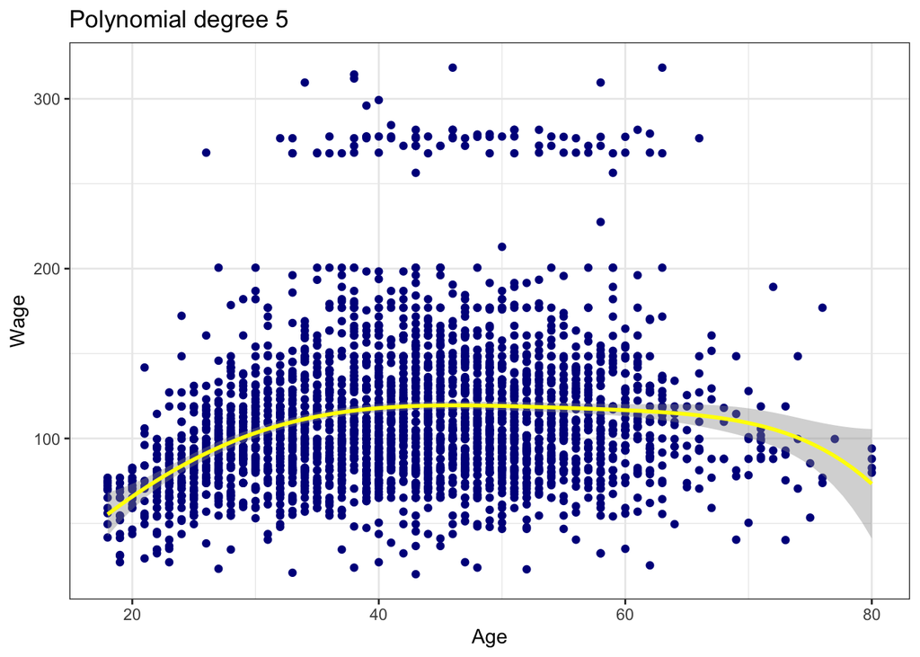

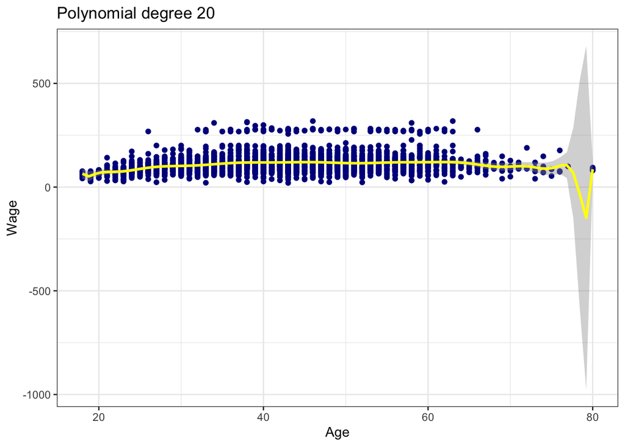

| Degree of the age polynomial | R-Squared |
| --- | --- |
| 2 | 0.2896871 |
| 3 | 0.2908565 |
| 4 | 0.2908565 |
| 5 | 0.2914362 |
| 6 | 0.2918935 |
| 7 | 0.2928255 |
| 8 | 0.2928256 |
| 9 | 0.2935562 |
| 10 | 0.2937707 |
| 11 | 0.2937954 |

[output cut: 9 more lines]

Even the higher degree give the higher $R^2$, the `overfitting` problem may be occured. Hence, polynomial regression with degree 3 would be appropriate.

```r
model_poly <- lm(wage ~ poly(age, 3) + education + year, data = data)
summary(model_poly)
```

```
##
## Call:
## lm(formula = wage ~ poly(age, 3) + education + year, data = data)
##
## Residuals:
##      Min       1Q   Median       3Q      Max
## -118.565  -19.789   -3.339   14.399  213.276
##
## Coefficients:
##                               Estimate Std. Error t value Pr(>|t|)
## (Intercept)                 -2247.6445   637.2171  -3.527 0.000426 ***
## poly(age, 3)1                 358.1166    35.4147  10.112  < 2e-16 ***
## poly(age, 3)2                -383.1188    35.3679 -10.832  < 2e-16 ***
## poly(age, 3)3                  78.2802    35.2489   2.221 0.026440 *
## education2. HS Grad            10.8127     2.4290   4.452 8.84e-06 ***
## education3. Some College       23.2840     2.5564   9.108  < 2e-16 ***
## education4. College Grad       37.8823     2.5414  14.906  < 2e-16 ***
## education5. Advanced Degree    62.4402     2.7584  22.636  < 2e-16 ***
## year                            1.1633     0.3177   3.662 0.000255 ***
## ---
## Signif. codes:  0 '***' 0.001 '**' 0.01 '*' 0.05 '.' 0.1 ' ' 1
##
## Residual standard error: 35.19 on 2991 degrees of freedom
## Multiple R-squared:  0.2909, Adjusted R-squared:  0.289
## F-statistic: 153.3 on 8 and 2991 DF,  p-value: < 2.2e-16
```

The $R^2$ is 0.2909, which improved from all previous models.

##### Basis Spline and Natural Spline

For both `Basis Spline` and `Natural Spline`, the number of knots or the degree of freedom need to be specified. One of the method used for specified is performing `K-fold Cross Validation`. In this case, K is equal to 5. For both types of spline, the highest degree of polynomial for age is 3.

- Basis Spline: df = 4 + knots
- Natural Spline: df = 2 + knots

Consider the MSE for basis spline.

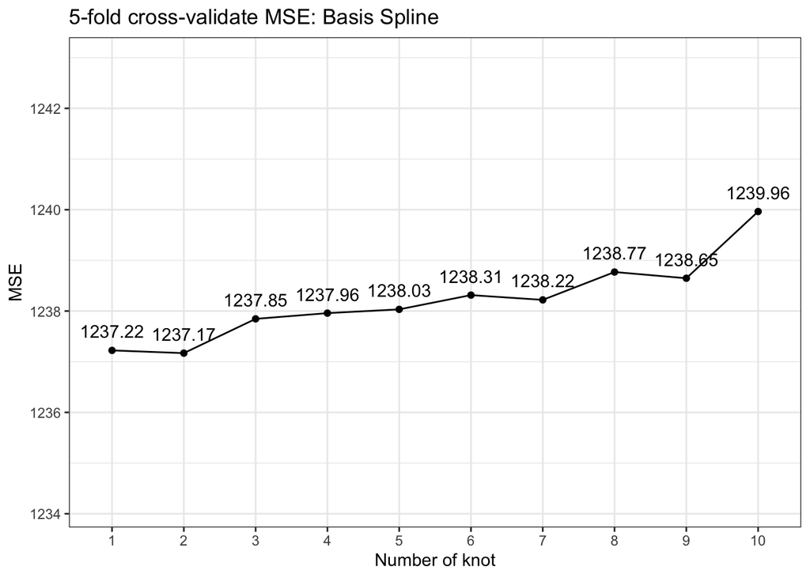

The MSE is lowest when the number of `knot` is equal to 2. Fit the regression with basis spline.

```r
model_basis <- lm(wage ~ bs(age, df = 6) + education + year, data = data)
summary(model_basis)
```

```
##
## Call:
## lm(formula = wage ~ bs(age, df = 6) + education + year, data = data)
##
## Residuals:
##      Min       1Q   Median       3Q      Max
## -120.371  -19.640   -3.273   14.086  213.170
##
## Coefficients:
##                              Estimate Std. Error t value Pr(>|t|)
## (Intercept)                 -2344.664    637.830  -3.676 0.000241 ***
## bs(age, df = 6)1               11.675     10.997   1.062 0.288473
## bs(age, df = 6)2               31.678      6.333   5.002 6.01e-07 ***
## bs(age, df = 6)3               46.964      7.371   6.372 2.16e-10 ***
## bs(age, df = 6)4               34.013      7.742   4.393 1.16e-05 ***
## bs(age, df = 6)5               48.731     12.143   4.013 6.14e-05 ***
## bs(age, df = 6)6                6.633     14.292   0.464 0.642610
## education2. HS Grad            11.075      2.430   4.557 5.41e-06 ***
## education3. Some College       23.638      2.562   9.227  < 2e-16 ***
## education4. College Grad       38.242      2.548  15.008  < 2e-16 ***
## education5. Advanced Degree    62.597      2.761  22.669  < 2e-16 ***
## year                            1.194      0.318   3.753 0.000178 ***
## ---
## Signif. codes:  0 '***' 0.001 '**' 0.01 '*' 0.05 '.' 0.1 ' ' 1
##
## Residual standard error: 35.17 on 2988 degrees of freedom
## Multiple R-squared:  0.2923, Adjusted R-squared:  0.2897
## F-statistic: 112.2 on 11 and 2988 DF,  p-value: < 2.2e-16
```

The $R^2$ is 0.2923.

Then consider the Natural Spline.

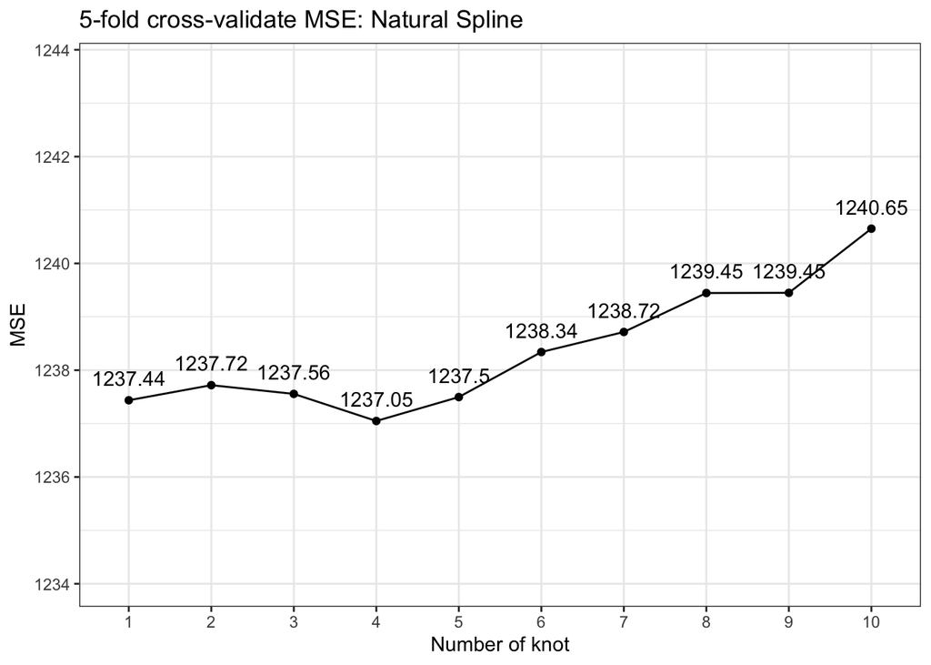

The MSE is lowest when the number of `knot` is equal to 4. Fit the regression with natural spline.

```r
model_natural <- lm(wage ~ ns(age, df = 6) + education + year, data = data)
summary(model_natural)
```

```
##
## Call:
## lm(formula = wage ~ ns(age, df = 6) + education + year, data = data)
##
## Residuals:
##      Min       1Q   Median       3Q      Max
## -121.403  -19.727   -3.143   14.174  214.340
##
## Coefficients:
##                               Estimate Std. Error t value Pr(>|t|)
## (Intercept)                 -2394.4450   638.1274  -3.752 0.000179 ***
## ns(age, df = 6)1               38.7338     4.6496   8.331  < 2e-16 ***
## ns(age, df = 6)2               46.4652     5.8970   7.879 4.57e-15 ***
## ns(age, df = 6)3               38.1178     5.1218   7.442 1.29e-13 ***
## ns(age, df = 6)4               37.0673     4.8062   7.712 1.67e-14 ***
## ns(age, df = 6)5               48.9899    11.6639   4.200 2.75e-05 ***
## ns(age, df = 6)6                4.3620     8.9214   0.489 0.624922
## education2. HS Grad            11.1264     2.4295   4.580 4.85e-06 ***
## education3. Some College       23.6491     2.5595   9.240  < 2e-16 ***
## education4. College Grad       38.3108     2.5454  15.051  < 2e-16 ***
## education5. Advanced Degree    62.5971     2.7605  22.676  < 2e-16 ***
## year                            1.2186     0.3182   3.830 0.000131 ***
## ---
## Signif. codes:  0 '***' 0.001 '**' 0.01 '*' 0.05 '.' 0.1 ' ' 1
##
## Residual standard error: 35.16 on 2988 degrees of freedom
## Multiple R-squared:  0.2927, Adjusted R-squared:  0.2901
## F-statistic: 112.4 on 11 and 2988 DF,  p-value: < 2.2e-16
```

The $R^2$ is 0.2927.